# Can Markets Be Predicted? Insights from GARCH Volatility Modeling and VAR Analysis of Sector Returns

Author

Peter Ward & Nick Kent

Published

December 16, 2025

Abstract

## Introduction

The Efficient Market Hypothesis (EMH) states that asset prices fully reflect all available information, implying that no trading strategy based solely on available information can consistently generate abnormal returns after adjusting for risk (Fama 1970). The weak form of the EMH restricts the information set to historical prices and returns, which implies that past returns should not provide any information about future returns (Fama 1970). Formally, under the weak form EMH, conditioning on past returns does not change the expected value of current returns,

$$E[R_t | R_{t-1}, R_{t-2}, \dots, R_{t-n}] = E[R_t]$$

An immediate implication of this condition is that returns are not linearly predictable and are uncorrelated over time,
$$Cov(R_t, R_{t-k}) = 0 \text{ for all k} \geq 1$$
However, the absence of linear predictability in returns does not imply that returns are independent or identically distributed, nor does it imply that their variance is constant over time (Fama 1970). In fact, a feature of financial returns is volatility clustering, where periods of high volatility tend to be followed by periods of high volatility, and periods of low volatility tend to persist (Sewell 2012). This empirical regularity is fully consistent with the weak form EMH and motivates the use of models that focus on forecasting the conditional variance of returns rather than their conditional mean.

To study volatility dynamics, we employ a Generalized Autoregressive Conditional Heteroskedasticity (GARCH) model using daily NASDAQ log return data. While the EMH suggests that past returns should not improve forecasts of future returns themselves, it does not rule out predictability in volatility. Therefore, although we expect the GARCH model to offer little improvement over a random walk in forecasting the level of returns, we hypothesize that it will provide meaningful insight into periods of heightened market uncertainty by capturing time-varying volatility around a zero mean.

If returns are unpredictable at the aggregate market level, a natural follow-up question is whether predictability may exist at the sector level. Different sectors of the stock market are exposed to common macroeconomic forces, such as changes in interest rates, economic growth, and financial crises, and they often exhibit strong co-movement. If shocks propagate across industries, then past returns in one sector may contain information that helps forecast returns in another. This raises the possibility that cross-sector dynamics could introduce limited predictability even if aggregate market returns remain unpredictable.

To motivate our sector-level analysis, we rely on existing empirical evidence that equity sectors within a stock market are strongly interconnected rather than independent. Prior research has shown that sectoral returns exhibit substantial cross-correlation and often respond collectively to market-wide shocks, especially during periods of high volatility or financial stress. For example, Sharma and Banerjee document strong contemporaneous and dynamic correlations across sectors in the Bombay Stock Exchange, with correlations intensifying during market downturns and large fluctuation periods. Their findings suggest that sector movements can be decomposed into a common market component and smaller sector-specific components, implying that shocks originating in one sector may transmit to others through shared exposure to macroeconomic conditions (Sharma and Banerjee 2015). Our analysis seeks to understand if the US stock market behaves the same way, with our research question being: Do Financials, Industrials, and Materials sectors exhibit cross sector return predictability at a one week horizon? In essence, we are trying to forecast future mean log returns at the weekly level for these three sectors using their past returns.

These documented connections between stock market sectors provide a strong reason for using a vector autoregression model in our analysis. A VAR is well suited for this setting because it treats all sector returns as jointly determined and allows each sector’s return to depend not only on its own past values but also on the past values of other sectors. Rather than assuming ahead of time which sectors influence others, the VAR framework lets the data reveal whether lagged returns in one sector help predict returns in another. In this setting, we expect that if sector relationships go beyond simply moving together at the same time, past returns from closely related sectors such as Financials, Industrials, and Materials may help explain short-term movements in each other’s returns. Testing this idea allows us to determine whether meaningful cross-sector predictability exists, or whether sector returns mainly respond simultaneously to shared economic shocks, which would be consistent with weak-form market efficiency.

## Data

All data for this analysis was gathered from Yahoo Finance via the *tidyquant* package (Yahoo Finance 2025; Dancho and Vaughan 2025). The project consists of two components: an analysis of market volatility using aggregate market data and an analysis of cross-sector return dynamics using sector-level data.

For the volatility analysis, we collected daily data on the Nasdaq Composite Index (IXIC). The dataset includes the date, opening and closing prices, daily high and low prices, trading volume, and the adjusted closing price, which accounts for dividends, stock splits, and other corporate actions. The sample spans from January 2, 1990 to December 5, 2025, yielding a total of 9,050 daily observations.

To examine cross-sector relationships, we gathered daily data for three equity sectors: Industrials (XLI), Financials (XLF), and Materials (XLB). These sectors were selected because of their broad exposure to the overall economy. For each sector, the dataset covers the period from January 3, 2000 to December 5, 2025 and includes the ticker symbol, date, opening and closing prices, daily high and low prices, trading volume, and adjusted closing prices. For clarity and interpretability, we created a sector name variable so that results could be discussed without relying on ticker symbols.

In both parts of the analysis, the primary variable of interest is the log return. For the volatility analysis, we computed daily log returns using the tq_transmute() function from tidyquant, which allows price data to be efficiently transformed into return series (Dancho and Vaughan 2025). Daily log returns are defined as:

$$R_t = ln(P_t) - ln(P_{t-1}) = ln(\frac{P_t}{P_{t-1}})$$
where $P_t$ is today’s adjusted closing price, $P_{t-1}$ is yesterday’s adjusted closing price, and $R_t$ is today’s log return. The Nasdaq Composite daily log returns can be seen in Figure 1. From Figure 1 it is apparent that Nasdaq daily log returns have a stationary mean of 0, but there is substantial volatility in the variance.

For the sector-level analysis, we focused on weekly log returns. Weekly returns were also calculated using tq_transmute() by taking the final adjusted closing price of each calendar week (Dancho and Vaughan 2025). Weekly log returns are defined as:

$$R_t^{weekly} = ln(P_{\text{end of week t}}) - ln(P_{\text{end of week t-1}}) = ln(\frac{P_{\text{end of week t}}}{P_{\text{end of week t-1}}})$$
where $P_{\text{end of week t}}$ is the last adjusted closing price of the current week and $P_{\text{end of week t-1}}$ is the last adjusted closing price of the previous calendar week. The weekly log returns for each sector can be seen in Figure 2, and the average mean weekly log returns for each sector can be seen in Figure 3. These two plots clearly demonstrate that weekly log returns for these three sectors largely move together (especially during global financial crises), with stationary mean returns around 0 and non-stationary variance, which motivates our cross-sector analysis.

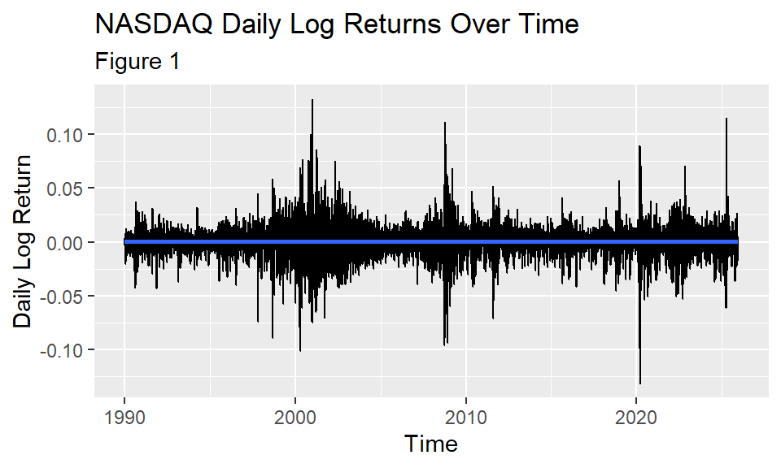

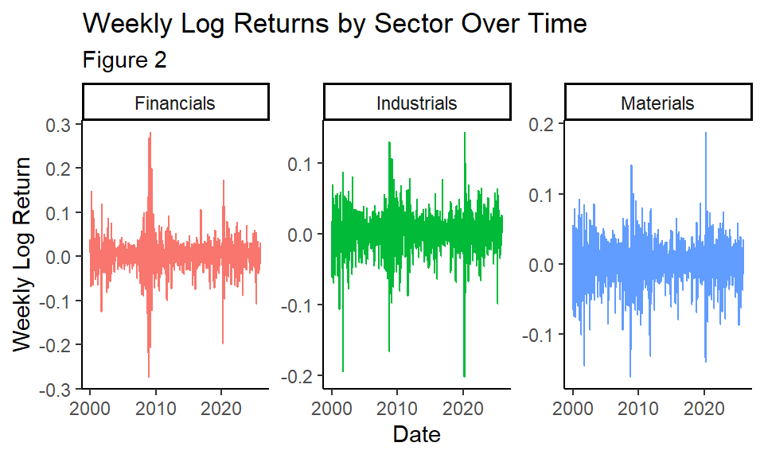

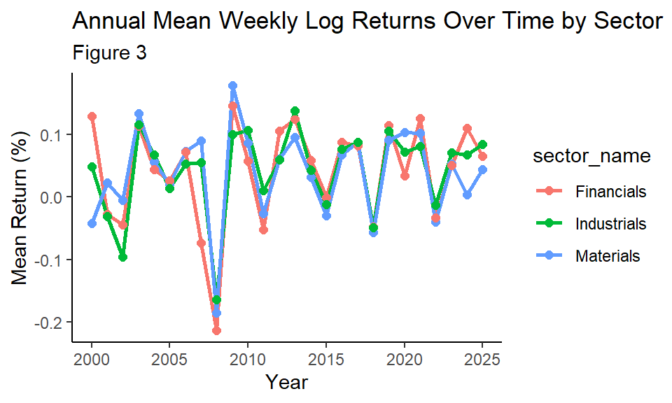

## Methods

### Part 1

Our objective here is to study market predictability. Even though we assume, based on the weak-form EMH, that past returns do not contain predictive information about future returns, we would like to know if volatility dynamics can be predicted (Fama 1970).

To do this we start by examining the correlation structure of the Nasdaq Composite daily log returns. Using the acf2() function from the astsa package we looked at the autocorrelation function (ACF) and the partial autocorrelation function (PACF) (Stoffer 2024). As we mentioned earlier, the weak-form EMH states that returns should be uncorrelated with one another, and therefore the ACF/PACF should display no autocorrelation, similar to a white noise process (Fama 1970; Hamilton 1994). If we do see some sort of correlation structure in these figures, that could suggest that using an ARMA model might improve forecasting.

To establish baseline predictability, we will fit two simple time series models: a random walk and a autoregressive order 1 (AR(1)) model (Hamilton 1994). A classic random walk model follows the following structure:
$$Y_t = Y_{t-1} + W_t \;\;\;\;\;W_t \stackrel{iid}{\sim} N(0, \sigma^2)$$

This implies that the value $Y_t$ is equal to last period’s value plus some normally distributed white noise with mean zero. But this equation describes how prices behave over time, not how returns behave, so we apply this equation to prices first:

$$P_t = P_{t-1} + W_t \;\;\;\;\;W_t \stackrel{iid}{\sim} N(0, \sigma^2)$$

Then, returns follow the following format:
$$R_t = \frac{P_t - P_{t-1}}{P_{t-1}}$$

So if prices follow a random walk then returns behave like white noise because they fluctuate around a constant mean and exhibit no correlation because each price change is driven entirely by the new shock $W_t$. After rearranging the two equations above we get the following:

$$R_t = \frac{W_t}{P_{t-1}} \;\;\;\;\;W_t \stackrel{iid}{\sim} N(0, \sigma^2)$$
This is precisely what the EMH states, returns behave like white noise because past price movements contain no information about future returns. Now, in addition to a random walk we also fit an AR(1) model using the sarima() function from the astsa package to test whether allowing returns to depend on their most recent lag has any impact (Stoffer 2024). If the weak-form EMH holds, then the AR(1) coefficient should be close to zero and the predictions from the model should be no better than the random walk model (Hamilton 1994). An AR(1) on returns looks like the following:

$$R_t = \phi R_{t-1} + W_t$$
Which shows that today’s return is a function of yesterday’s return plus some random noise. Now even though we fit a random walk and an AR(1) model, we assume that these models will not have any statistical power.

Therefore, our focus is going to shift to examining whether the volatility of returns can be forecasted. In other words, can yesterday’s uncertainty be used to predict tomorrow’s uncertainty. As we’ve seen from Figure One, the return process has a mean of zero, is serially uncorrelated, and has a non-constant variance, which points us towards an ARCH-type process (Engle 1982). So we test for conditional heteroskedasticity and then estimate a couple of GARCH models which are used to forecast future variance. First we need to check for the need of GARCH models which we do by examining the ACF/PACF of the squared returns and conduct an ARCH test using the ArchTest() function from FinTS package (Engle 1982; Tsay 2024). We start by specifying a standard Generalized Autoregressive Conditional Heteroskedasticity (GARCH(1,1)) model, this is an extension of the ARCH framework (Bollerslev 1986). This models assumes that positive and negative shocks have the same effect on volatility and follows the following form:

$$\text{Returns: }R_t = \mu + \epsilon_t, \;\;\; \epsilon_t = \sigma_t z_t, \;\;\; z_t\stackrel{iid}{\sim} N(0,1)$$
$$\text{and the conditional variance: } \sigma_t^2 = W + \alpha \epsilon^2_{t-1} + \beta \sigma^2_{t-1}$$
$$W = \text{baseline variance}, \alpha = \text{reaction to last periods shock}, \beta = \text{persistence of volatility}$$

After looking at the results of that model, we then specify an Exponential Generalized Autoregressive Conditional Heteroskedasticity (EGARCH) model which allows negative shocks to increase volatility more than positive ones. For all 4 of our models we split our data into a training set with 25 years of data and a test set of 10 years of data to compare out of sample prediction. We compare all of the models based on the mean squared error of their return forecasts. We also evaluate the quality of the volatility predictions by comparing the models estimated conditional variance to the actual volatility (squared actual returns).

### Part 2

For the sector-specific part of our analysis, we focused on three equity sectors: Financials, Materials, and Industrials. We chose these sectors because they show moderate correlation with one another and because all three tend to react to broad macroeconomic changes. This made them good candidates for studying how returns move together and whether information from one sector can help predict another. To control for major structural shifts in the market during our sample period, we also created indicator variables for the major recessionary periods. These included the dot-com crash from 2000 to 2002, the Global Financial Crisis from 2007 to 2009, and the COVID-19 downturn in early 2020. These crisis variables were included in the model as exogenous predictors so that unusually large negative shocks during those periods would not distort the normal return dynamics. We split the data into test and train datasets, with the train dataset containing observations from 2000 to 2019, and the test dataset containing observations from 2020 to 2025. This allowed us to use our VAR model to forecast returns for each sector from 2020 to 2025, and compare these forecasts to the observed values in our data.

We applied a vector autoregression (VAR) (Sims 1980) model to our training data to examine whether past weekly returns from each sector, as well as past returns from the other sectors, contain any useful information for predicting future returns. A VAR is a statistical model that treats all variables in the system as potentially influencing one another over time (Sims 1980). Instead of modeling each sector separately, a VAR allows every sector’s return to depend on its own lagged values and the lagged values of the other sectors in the system. This makes it especially useful for studying financial markets, where different sectors often move together in response to macroeconomic news. By estimating a VAR, we were able to test whether lagged returns from Industrials, Financials, or Materials provide any predictive power for future returns in any of the other sectors.

The VAR equations are similar to that of an AR(1) model, except lagged returns from the other two sectors are included in addition to lagged returns of a given sector. Each equation models the weekly log return of one sector as a function of: its own return from last week, the returns of the other two sectors from last week, crisis indicators that capture major market downturns, and a random error term. For example, the Industrials equation says that the Industrials return this week depends on: last week’s Industrials return, last week’s Financials return, last week’s Materials return, whether the economy is in a crisis period, and an unpredictable shock specific to Industrials.

Before estimating the VAR model, we used the VARselect (Pfaff 2023) function to determine how many lags of each variable should be included. In a VAR model, the lag length controls how far back in time the model looks when trying to explain current movements in each sector’s returns. For example, a VAR(1) model uses the previous week’s returns, while a VAR(4) model would use the previous four weeks. Choosing the lag length is important because it affects both the fit and interpretation of the model. If we include too few lags, we risk leaving out important past information that might help predict current returns. If we include too many lags, we can overfit the data and introduce unnecessary noise. The VARselect function evaluates several statistical criteria, such as the Akaike Information Criterion (AIC) and the Schwarz Criterion (SC), to suggest a lag length that balances model complexity with predictive accuracy (Pfaff 2023). In our case, the more conservative criteria recommended using only one lag, while the others recommended 4 lags. Taking this information into account, we preferred the simpler VAR(1) model and chose to fit it with a constant term and the crisis indicators as exogenous variables. The system of equations below details our VAR(1) model equations for each sector:

$$\begin{aligned}
\text{Industrials}_t
&= c_1
+ \phi_{11}\,\text{Industrials}_{t-1}
+ \phi_{12}\,\text{Financials}_{t-1}
+ \phi_{13}\,\text{Materials}_{t-1}
+ \boldsymbol{\gamma}_1^{\top}\mathbf{X}_t
+ \varepsilon_{1t}, \\
\text{Financials}_t
&= c_2
+ \phi_{21}\,\text{Industrials}_{t-1}
+ \phi_{22}\,\text{Financials}_{t-1}
+ \phi_{23}\,\text{Materials}_{t-1}
+ \boldsymbol{\gamma}_2^{\top}\mathbf{X}_t
+ \varepsilon_{2t}, \\
\text{Materials}_t
&= c_3
+ \phi_{31}\,\text{Industrials}_{t-1}
+ \phi_{32}\,\text{Financials}_{t-1}
+ \phi_{33}\,\text{Materials}_{t-1}
+ \boldsymbol{\gamma}_3^{\top}\mathbf{X}_t
+ \varepsilon_{3t}.
\end{aligned}$$
where:

$$\mathbf{X}_t =
\begin{bmatrix}
\text{crisis\_dotcom}_t \\
\text{crisis\_gfc}_t
\end{bmatrix}
\quad \text{or} \quad
\mathbf{X}_t =
\begin{bmatrix}
\text{crisis\_dotcom}_t \\
\text{crisis\_gfc}_t \\
\text{crisis\_covid}_t
\end{bmatrix}$$
and:

**$\text{Industrials}_t$, $\text{Financials}_t$, $\text{Materials}_t$**

weekly log returns at time $t$.

**$c_i$**

constant term in equation $i$.

**$\phi_{ij}$**

effect of sector $j$ at $t-1$ on sector $i$ at $t$.

**$X_t$**

vector of exogenous variables (crisis indicators).

**$\gamma_i$**

coefficients on $X_t$ in equation $i$.

**$\varepsilon_{i,t}$**

error term with mean zero and finite variance.

After fitting the model, we carried out several diagnostic and exploratory steps. We checked for serial correlation using the Portmanteau test (Ljung and Box 1978) and by examining the autocorrelation functions (ACFs) of the residuals for each sector. We then used forecast error variance decomposition (FEVD) (Sims 1980) to see how much of each sector’s return variability could be explained by shocks in the other sectors. We also generated impulse response functions (IRFs) (Pfaff 2008) to examine how a one time shock to one sector affects the others and how it persists over time. Granger causality tests (Granger 1969) were used to evaluate whether lagged returns from one sector provide any statistically significant predictive value for another sector. Finally, we created short term forecasts from 2020 to 2025 for all three sectors using the fitted VAR(1) model and compared them to the observed values, assuming that there would be no recessionary periods during the forecast horizon.

## Results

### Part 1

Below we see the ACF/PACF of the daily log returns. We see no decay in the ACF or cutoff in the PACF which implies that the daily returns are uncorrelated with one another.

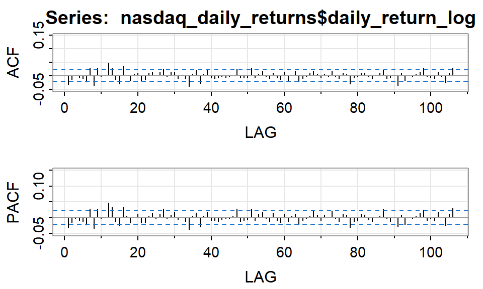

We now fit a random walk model as benchmark. Under a random walk for prices returns are roughly mean zero white noise, which means the forecast for future values is zero. After making predictions with this model on the data after 2016 we get a mean squared error of 0.000194.

Although the ACF and PACF above gave us no evidence of an AR structure, we still fit an AR(1) model for comparison to the random walk model and to test the EMH. After fitting this model we see that the AR(1) coefficient is estimated to be 0 and has a very high p-value (~0.99), meaning it is statistically insignificant. This indicates that there is no need for an AR(1) for returns. Finally, we also forecasted future returns using the AR(1) model and compared them to the true data after 2016, the mean squared error was 0.000194. Furthermore, when we assume the volatility is constant, meaning my best guess for tomorrow’s variance is the average variance from the past, the MSE of the variance forecast is $4.104484 \times 10^{-07}$. This is very similar to the MSE of the variance forecast from the random walk model, $4.104501 \times 10^{-07}$.

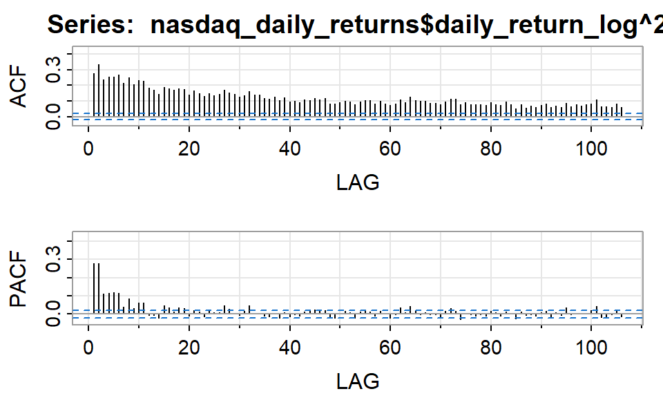

We then test for conditional heteroskedasticity (whether or not the variance is constant over time) using an ARCH test. The null hypothesis, that no ARCH effects exist, is strongly rejected with a p-value that is very close to 0. This gives evidence of time varying conditional variance.

Therefore, we fit two models. First a GARCH(1,1). The mean return is estimated to be 0.000734 which is positive but not economically significant or different from zero. The variance dynamics, $\alpha$ equals 0.09 and $\beta$ = 0.9 ($\alpha + \beta$ = 0.99), tell us that volatility reacts to new information (large unexpected returns today increase the forecasted variance tomorrow) and volatility is persistent. We also conduct a sign bias test, which checks to see whether volatility responds differently to negative and positive shocks. The t-statistic is 3.9 and the p-value is less than 0.001. This suggests that volatility responds differently depending on the sign of the shock.

This motivates us to fit an EGARCH model. The estimated $\beta$ coefficient is 0.987365 which means volatility is very persistent. The $\gamma$ coefficient is 0.156 and statistically significant, which means the sign of past return shocks matter for future volatility. Finally, the $\alpha$ coefficient is -0.083 and statistically significant which means that todays volatility depends on how big past shocks were. Bayesian Information Criterion (BIC) for EGARCH = -6.0914 and BIC for GARCH = -6.0526 meaning the EGARCH model is a better fit for our data.

We then make predictions on the data after 2016 using both models. The MSE on return forecasts for the GARCH model is 0.000193 and the MSE for the EGARCH model is 0.000197. This tells us that neither the GARCH or EGARCH models make better mean predictions then the random walk. Then, the MSE from the variance forecast using the GARCH model is $3.404114 \times 10^{-07}$ and the MSE from the variance forecast using the EGARCH model is $3.31474 \times 10^{-07}$.

Finally, below we have a plot of the true squared returns as well as the forecasted variance from both the GARCH and EGARCH models. Both models produce relatively good forecasts, but the EGARCH model create more sharp predictions and has a better overall structure that is consistent with the true values of the squared returns.

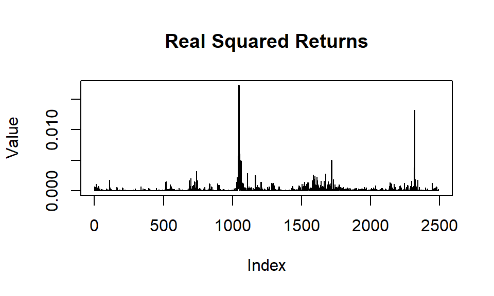

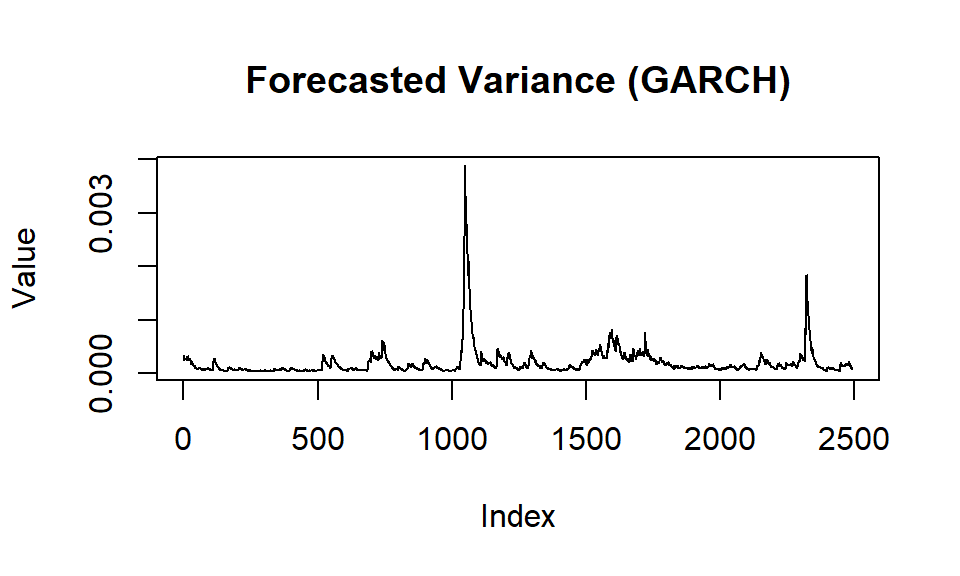

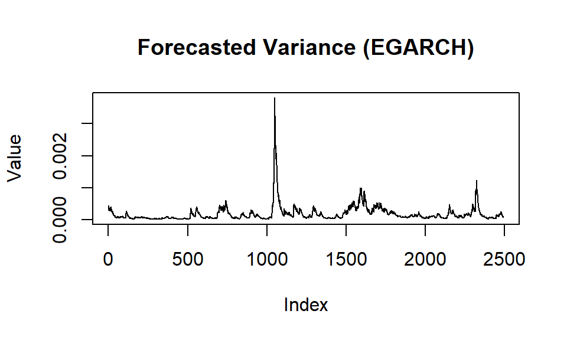

### Part 2

We began by checking the adequacy of the VAR(1) model that was fit using the data from 2000 through 2019. The Portmanteau test showed evidence of remaining autocorrelation in the residuals, which means the model does not perfectly remove all time dependence. However, when we examined the autocorrelation function plots for each sector, almost all of the correlation disappeared after lag one. This indicates that the VAR(1) model captures the majority of the serial dependence. All roots of the estimated system were less than one in absolute value, confirming that the model is stable and that the impulse response functions can be interpreted reliably.

We then examined the estimated equations for the Industrials, Financials, and Materials sectors. In the Industrials equation, none of the lagged returns were statistically significant at the five percent level. Financials lag one had a p-value around 0.091, which is close to significant, but the estimated coefficient was small and does not indicate any real predictive power. This shows that last week’s returns provided very little information for predicting Industrials.

The crisis indicators behaved as expected. The Global Financial Crisis dummy was significantly negative in all three equations, indicating that returns were consistently lower during this period. The dot com dummy was not significant in any equation, which may reflect that this period affected these three sectors less severely than others in the market. Despite the clear impact of crisis periods, all three equations had very low R squared values. This means that most of the variation in weekly returns is driven by random noise and not captured by the VAR(1) model, which is consistent with the weak form of the Efficient Market Hypothesis.

The impulse response functions support these findings. A shock to any one sector produced a strong immediate response in that sector, but the effect faded rapidly, usually after only one or two weeks. Cross sector responses were small and short lived. Shocks to Industrials created the largest spillover effects, while shocks to Financials and Materials had weaker effects on the other sectors. Overall, the impulse responses show that even though the sectors react at the same time to new information, any spillover from one sector to another fades almost immediately.

Finally, we used the VAR model fit on the training data to forecast returns from 2020 through 2025, and we compared these forecasts to the actual returns during that period. The forecasted values for all three sectors were essentially constant at zero across the entire test period. The forecast lines appear as horizontal lines in the plots, while the actual returns show large and frequent swings around zero. This happens because the VAR(1) model fails to capture the volatility present in weekly returns and therefore predicts the long run mean of zero for every future week. These forecast results emphasize that even when using information from the entire training period, the model is unable to produce meaningful forecasts. This finding matches the evidence from the Granger causality tests, which showed no significant predictive relationships among the sectors except for a weak causal effect from Materials on Industrials and Financials.

Taken together, these results indicate that weekly returns for the Industrials, Financials, and Materials sectors are very difficult to predict. Although the sectors tend to move together when major economic shocks occur, their week to week movements are dominated by randomness. The VAR model provides almost no predictive value, which supports the idea that past returns do not help forecast future returns in these sectors.

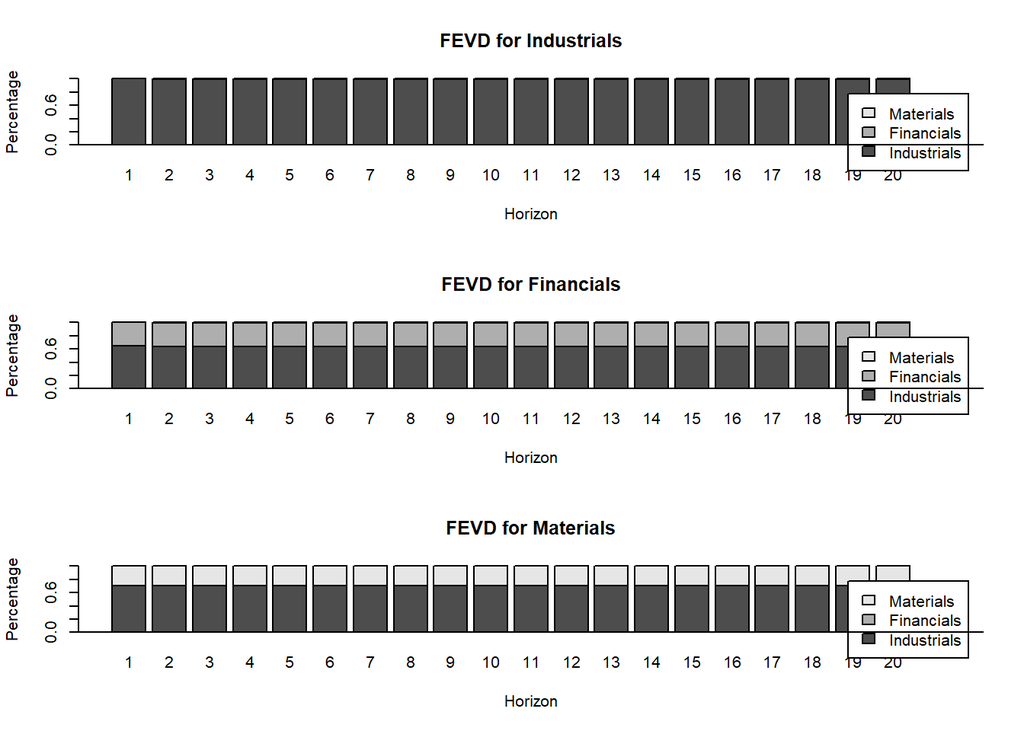

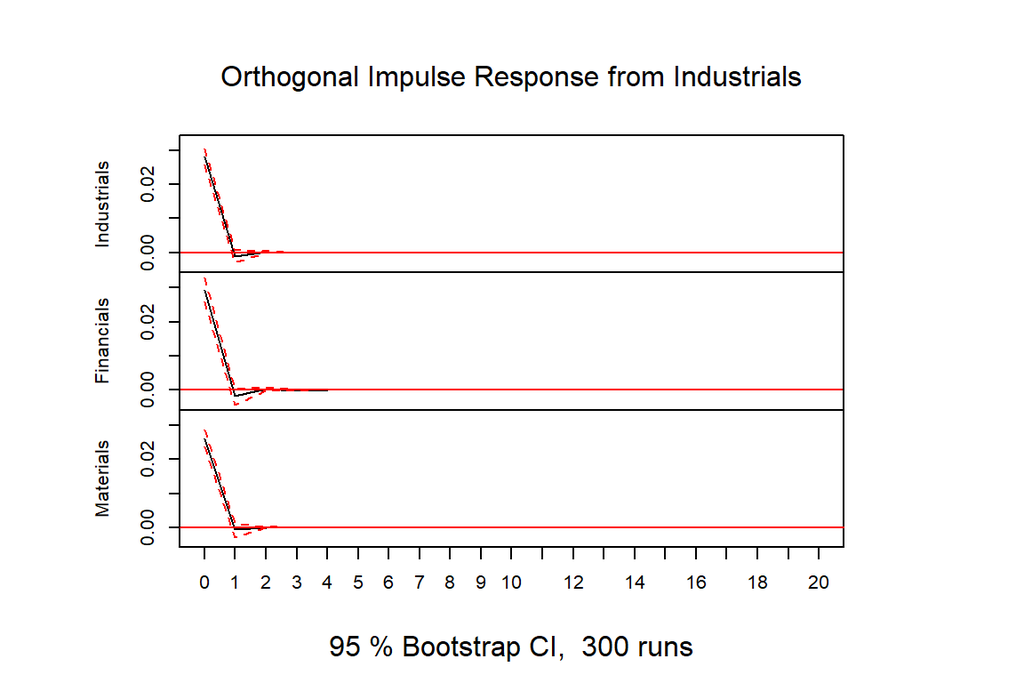

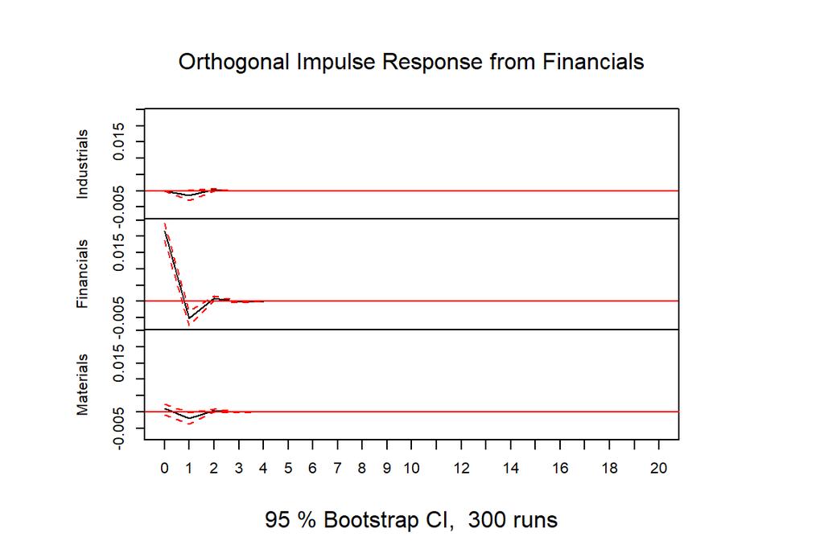

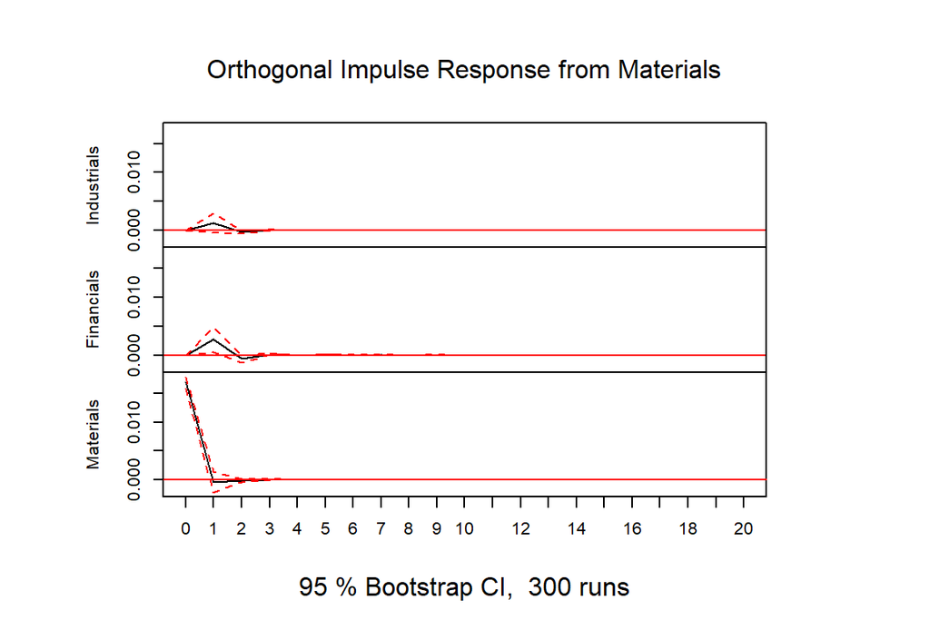

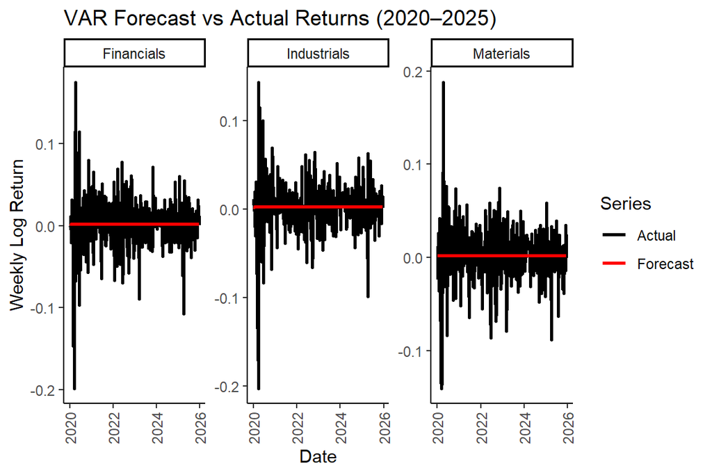

## Conclusions

### Part 1

In summary, the ACF and PACF of log returns show no evidence of correlation which is consistent with the weak-form Efficient Market Hypothesis and implies that conditioning on past returns will not help with predicting future returns. We tested this using a benchmark of a random walk and an AR(1) model and saw that they yielded very similar out-of-sample forecast accuracy. Assuming constant volatility with the random walk and AR(1) model, they had nearly identical accuracy in terms of variance forecasts.

In contrast, the ACF and PACF of squared returns showed strong and persistent dependence which gives evidence of volatility clustering. After conducting an ARCH test we strongly rejected the null hypothesis of constant variance and this motivated us to use ARCH models. After fitting a simple GARCH model we captured clear volatility dynamics such as persistence and sensitivity to new shocks, but this model assumed symmetric responses to shocks. The sign bias tests strongly pointed us towards using an EGARCH model for asymmetric volatility responses (negative and positive return shocks have a different effect on future volatility). The EGARCH model proved to be a better fit for the data, shown through a lower Bayesian Information Criterion. While neither the GARCH or EGARCH model proved to provide better return forecasts relative to a random walk, they both provided much more accurate variance forecasts, with the EGARCH model slightly outperforming the GARCH model.

### Part 2

In the sector specific portion of our analysis, we find strong evidence that a vector autoregression model has very limited forecasting ability for weekly stock returns. Across Industrials, Financials, and Materials, the VAR(1) model consistently showed that lagged returns from other sectors provide little to no predictive information for future returns. The Granger causality tests supported this conclusion, as almost all cross sector relationships were statistically insignificant or economically negligible. Together, these results indicate that knowing how other sectors performed last week does not meaningfully improve forecasts for a given sector. We find that shocks tend to affect all sectors at the same time, but the cross sector effects fade quickly and do not persist beyond one or two weeks. This suggests that sectors respond simultaneously to common macroeconomic information rather than transmitting shocks to one another over time.

The out of sample forecasts provide the clearest evidence of the model’s limitations. When the VAR model fit on pre 2020 data was used to forecast returns from 2020 through 2025, the predicted returns for all three sectors converged immediately to zero and remained flat over the entire forecast horizon. In contrast, the actual returns displayed substantial volatility around zero. This outcome highlights a fundamental limitation of linear VAR models for return prediction. While the model can capture average behavior, it is unable to account for the large and unpredictable swings that characterize weekly stock returns. As a result, the VAR effectively produces the trivial forecast that next week’s return will be zero plus noise. Evidently, this forecast would not be very useful for an investor hoping to use its predictions to maximize future returns, as it doesn’t provide any insight into the risks associated with the investment.

Overall, these findings provide strong support for the weak form Efficient Market Hypothesis. Even when allowing for cross sector interactions and controlling for major financial crises, past returns do not meaningfully predict future returns. Although sectors clearly move together during major economic shocks, this co-movement does not translate into usable forecasting power at the weekly horizon. Our initial hypothesis that sector interdependence might generate predictive relationships was not supported by our findings.

However, there are several key limitations to this analysis. First, we restricted our VAR to only three sectors at a time due to computational and practical constraints. Including a larger number of sectors could provide a more complete picture of market wide dynamics, although higher dimensional VAR models become increasingly difficult to estimate and interpret. Second, we focused on a VAR(1) specification, which was justified by standard information criteria but may still miss longer lagged relationships. Future work could explore alternative lag structures, nonlinear models, or different combinations of sectors, and investigate if the volatility of weekly returns is also predictable at the sector-level. Combining a VAR model with volatility based approaches may offer a more complete understanding of the risks associated with sector-specific investments.

Despite these limitations, our results clearly show that while sector returns are correlated and react together to shared shocks, their week to week movements are largely unpredictable. This reinforces the idea that predictability in financial markets is extremely limited at short horizons, even when accounting for cross sector dynamics.

## Acknowledgements

We would like to thank Professor Brianna Heggeseth for her guidance and feedback throughout this process. We would also like to thank the authors of all R packages used in this analysis as well as the authors of the articles we referenced.

## References

Bollerslev, Tim. 1986. “Generalized Autoregressive Conditional Heteroskedasticity.” *Journal of Econometrics* 31 (3): 307–27. https://doi.org/10.1016/0304-4076(86)90063-1.

Dancho, Matt, and Davis Vaughan. 2025. *Tidyquant: Tidy Quantitative Financial Analysis*. https://doi.org/10.32614/CRAN.package.tidyquant.

Engle, Robert F. 1982. “Autoregressive Conditional Heteroscedasticity with Estimates of the Variance of United Kingdom Inflation.” *Econometrica* 50 (4): 987–1007. http://www.jstor.org/stable/1912773.

Fama, Eugene F. 1970. “Efficient Capital Markets: A Review of Theory and Empirical Work.” *The Journal of Finance* 25 (2): 383–417. https://www.jstor.org/stable/2325486.

Granger, Clive W. J. 1969. “Investigating Causal Relations by Econometric Models and Cross-Spectral Methods.” *Econometrica* 37 (3): 424–38.

Hamilton, James D. 1994. “Stationary ARMA Processes.” In *Time Series Analysis*, 43–71. Princeton University Press. http://www.jstor.org/stable/j.ctv14jx6sm.6.

Ljung, Greta M., and George E. P. Box. 1978. “On a Measure of Lack of Fit in Time Series Models.” *Biometrika* 65 (2): 297–303.

Pfaff, Bernhard. 2008. *VAR, SVAR and SVEC Models: Implementation Within r Package Vars*. *Journal of Statistical Software*. Vol. 27. https://www.jstatsoft.org/article/view/v027i04.

———. 2023. *Vars: VAR Modelling*. https://CRAN.R-project.org/package=vars.

Sewell, Martin. 2012. “The Efficient Market Hypothesis: Empirical Evidence.” *International Journal of Statistics and Probability* 1 (2): 164–78. https://doi.org/10.5539/ijsp.v1n2p164.

Sharma, Chandradew, and Kinjal Banerjee. 2015. “A Study of Correlations in the Stock Market.” *arXiv Preprint arXiv:1504.05109*.

Sims, Christopher A. 1980. “Macroeconomics and Reality.” *Econometrica* 48 (1): 1–48.

Stoffer, David. 2024. *Astsa: Applied Statistical Time Series Analysis*. https://CRAN.R-project.org/package=astsa.

Tsay, Ruey S. 2024. *FinTS: Companion to Tsay (2005) Analysis of Financial Time Series*. https://cran.r-project.org/web/packages/FinTS/index.html.

Yahoo Finance. 2025. “Yahoo Finance.” https://finance.yahoo.com/.